# Управление загрузкой системы

Майоров Дмитрий Андреевич

# Информация

## Докладчик

- Майоров Дмитрий Андреевич

# Цель работы

Получить навыки работы с загрузчиком системы GRUB2.

# Выполнение лабораторной работы

Запускаем терминал, получаем полномочия администратора. В файле /etc/default/grub устанавливаем параметр GRUB_TIMEOUT=10. Далее записываем изменения в GRUB2 c помощью следующей команды

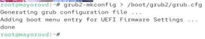

Рисунок 1

# Выполнение лабораторной работы

Перезагружаем систему. В меню GRUB выбираем строку с текущей версией ядра и открываем редактирование. В нужной строке вводим следующую команду и удаляем опции rhgb и quit.

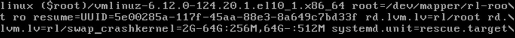

Рисунок 2

# Выполнение лабораторной работы

Смотрим список всех файлов модулей загруженных в настоящее время

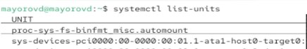

Рисунок 3

# Выполнение лабораторной работы

Смотрим задействованные переменные среды оболочки

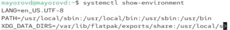

Рисунок 4

# Выполнение лабораторной работы

Перезагружаем систему. В меню GRUB выбираем строку с текущей версией ядра и открываем редактирование. В нужной строке вводим следующую команду и удаляем опции rhgb и quit.

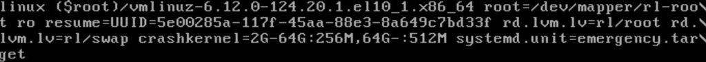

Рисунок 5

# Выполнение лабораторной работы

Смотрим список всех файлов модулей загруженных в настоящее время

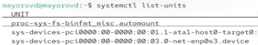

Рисунок 6

# Выполнение лабораторной работы

Перезагружаем систему. В меню GRUB выбираем строку с текущей версией ядра и открываем редактирование. В нужной строке вводим следующую команду и удаляем опции rhgb и quit.

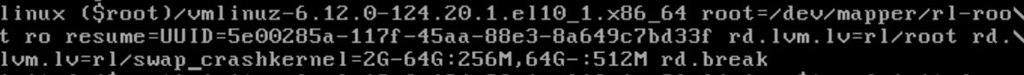

Рисунок 7

# Выполнение лабораторной работы

# Выполнение лабораторной работы

# Выполнение лабораторной работы

Загружаем политику SELinux

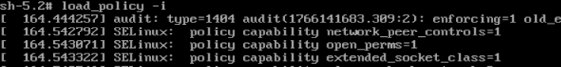

Рисунок 10

# Выполнение лабораторной работы

Вручную устанавливаем правильный тип контекста для /etc/shadow

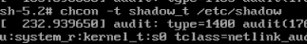

Рисунок 11

# Выполнение лабораторной работы

Перезагружаем систему и входим под новым паролем

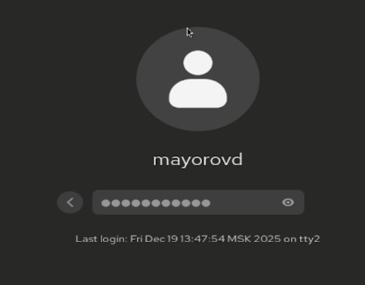

Рисунок 12

# Выводы

Получены навыки работы с загрузчиком системы GRUB2.